© Guven

# Introduction to Recurrent Neural Networks

(source: Rao, Delip, and Brian McMahan. Natural Language Processing with PyTorch: Build Intelligent Language Applications Using Deep Learning. " O'Reilly Media, Inc.", 2019.)

## Introduction

A sequence is an ordered collection of items. Classical approaches, such as N-gram language models, assumes data points to be independently and identically distributed (IID), but in many situations (like with language, speech, and time series data), given one data item, it depends on the items that precede or follow it. For example, speech is a sequence of phonemes. In English language, words in a sentence form sequences as we have seen in previous modules, such as word tagging. As an example, the preposition 'of' is likely followed by the article 'the'.

In deep learning, modeling sequences involves maintaining hidden *state information,* similar to Hidden Markov Models. As each item in the sequence is encountered, the hidden state is updated. Thus, the hidden state (usually a vector) encapsulates everything seen by the sequence so far. This hidden state vector, also called a sequence representation, can then be used in many sequence modeling tasks such as `Word2Vec`.

## Recurrent Neural Networks

In PyTorch, Recurrent Neural Networks, like Feedforward networks, are a family of models, and they model sequences of tensors. In the following cells, we will use Elman RNNs which one of many available in PyTorch. The representation of a sequence is *learned* by maintaining a hidden state vector that captures the current state of the sequence. The hidden state vector is computed from both the current input vector and the previous hidden state vector. Below, left figure is the functional and the right figure is the "unrolled" view of the computational dependencies. In the case of an Elman RNN, the hidden vector is what is predicted.

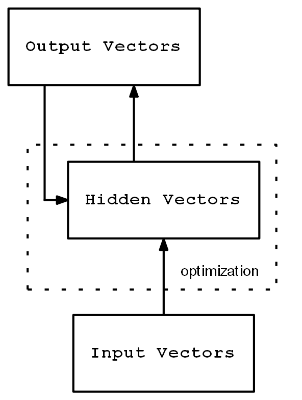

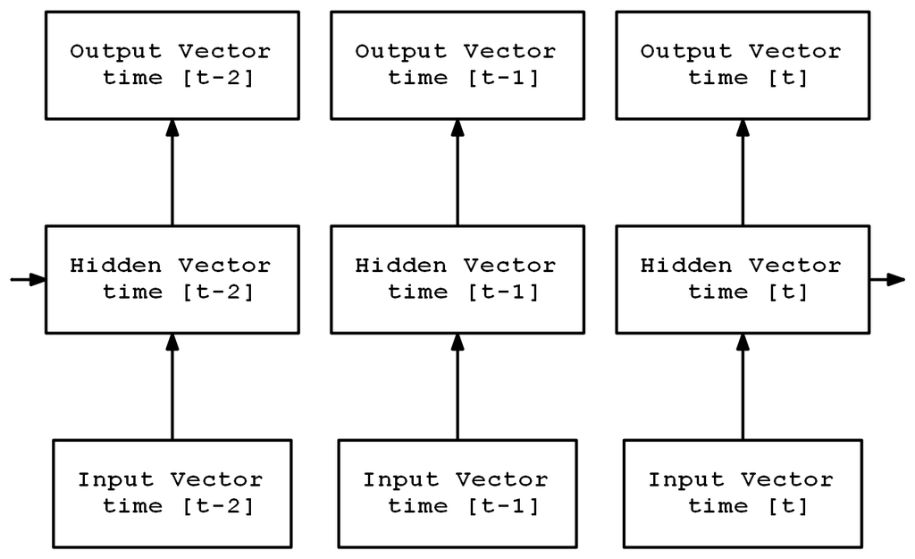

The back-propagation through time (BPTT) is used, where the input vector from the current time step and the hidden state vector from the previous time step are mapped to the hidden state vector of the current time step. A new hidden vector is computed using a hidden-to-hidden weight matrix to map the previous hidden state vector and an input-to-hidden weight matrix to map the input vector. The hidden-to-hidden and input-to-hidden weights are shared across the different time steps.

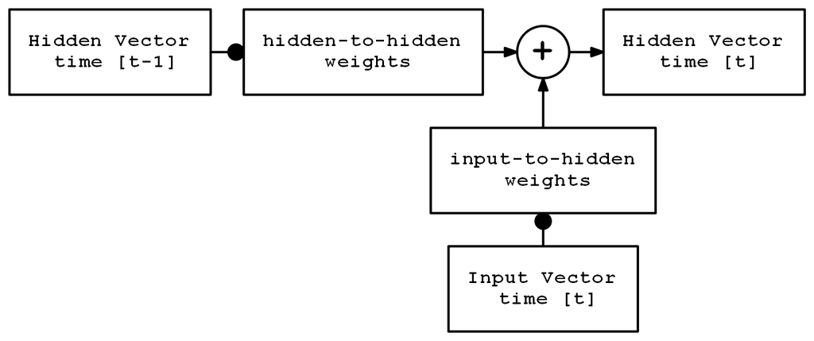

RNNs use the same parameters to compute outputs at every time step by relying on a hidden state vector to capture the state of the sequence. In this way, the goal of RNNs is to learn sequence invariance by being able to compute any output given the hidden state vector and the input vector. For compare/contrast reference, an RNN shares parameters across **time** and a CNN (Convolutional Neural Networks) shares parameters across **space**.

- RNN $\longrightarrow$ temporal (such as signal, speech, NLP)
- CNN $\longrightarrow$ spatial (such as images)
- Then video $\longrightarrow$ CNN + RNN

As words and sentences can be of different lengths, the RNN or any sequence model should be equipped to handle variable length sequences. One possible solution is to restrict sequences to a fixed length artificially. Another technique, called masking takes advantage of knowledge of the lengths of the sequences. In brief, masking allows for the data to signal when certain inputs should not count toward the gradient or the eventual output. PyTorch provides primitives for handling variable length sequences called `PackedSequences` that create dense tensors from these less dense ones.

### Drawbacks of RNNs

Saturation, vanishing/exploding gradients, complex loss surfaces and numerous local minima, not going well with dropout are among the problems with RNNs. LSTMs and GRUs address some of these issues. Generally RNNs are difficult to train.

Some references addressing these issues:

- Merity, Stephen, Nitish Shirish Keskar, and Richard Socher. "Regularizing and optimizing LSTM language models." arXiv preprint arXiv:1708.02182 (2017).
- Veličković, Petar, et al. "Graph attention networks." arXiv preprint arXiv:1710.10903 (2017).

## Elman RNN

The PyTorch RNN class implements the Elman RNN directly. Below is an indirect implementation of the Elman RNN using the `RNN` layer. The class `My_RNN`, utilizes `RNN` to create the input-to-hidden and hidden-to-hidden weight matrices. Each call to `RNN()` accepts a matrix of input vectors and a matrix of hidden vectors. It returns the matrix of hidden vectors that results from one step or batched. Batched learning is achieved by training in parallel, and it is fully scalable as long as the 3D Tensor fits in the GPU memory.

In addition to controlling the input and hidden size hyperparameters in the RNN, there is a Boolean argument for specifying whether the sequence dimension `T` will be on the 0<sup>th</sup> dimension. This flag is present in all PyTorch RNNs implementations, as well. When set to True, the RNN swaps the 0<sup>th</sup> and 1<sup>th</sup> dimensions on the input tensor, setting the batch dimension `B` as first dimension and `T` as the second. Features dimension `M` comes last.

In the `My_RNN` class, the forward() method internally loops over the input tensor to compute the hidden state vector for each time step, guided by the sequence dimension `T`. Notice that there is an option for specifying the initial hidden state (i.e. layer), but if it is not provided, a default hidden state vector of all 0s is used. As the `RNN` class loops over the length of the input vector, it computes a new hidden state.

These hidden states are aggregated and ultimately stacked. Before they are returned, the `batch_first` flag is checked again. If it is True, the output hidden vectors are permuted so that the batch is once again on the 0<sup>th</sup> dimension. The output of the class is a three-dimensional tensor, i.e. there is a hidden state vector for each data point on the batch dimension and each time step. We can use these hidden vectors in many ways, depending on the task at hand. One way that we can use them is to classify each time step to some discrete set of options. This method means that the RNN weights will be adjusted to track information relevant to predictions at each time step.

## Long Short-Term Memory RNN

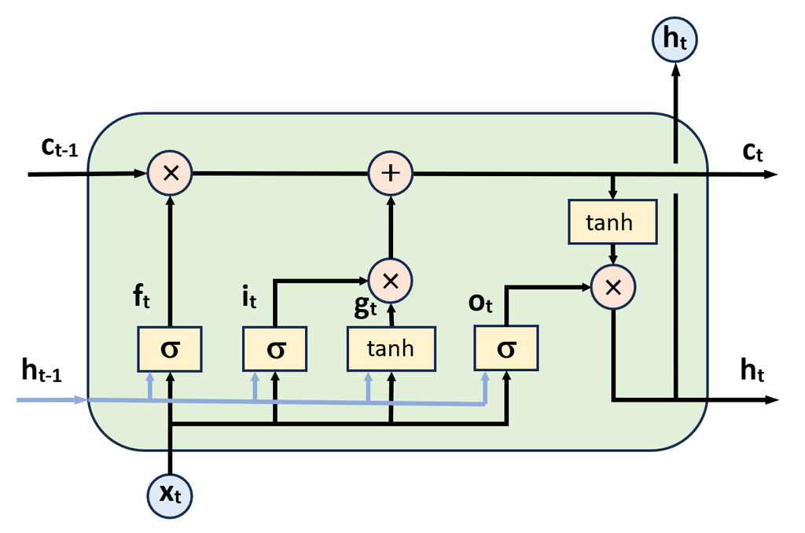

In practice, RNNs are particularly susceptible to the *vanishing gradient* problem, or potentially *exploding gradient* due to the nature of the feedback network and a high learning rate. A new RNN type is invented as the Long Short-Term Memory (LSTM) variant of the RNN which has three gates (layers) for more control:

- input gate  
  $i_t = \sigma \left(W_{ii}x_t + b_{ii} + W_{hi}h_{t-1}+b_{hi} \right)$  
  $g_t = \tanh \left(W_{ig}x_t + b_{ig} + W_{hg}h_{t-1}+b_{hg} \right)$
- output gate  
  $o_t = \sigma \left(W_{io}x_t + b_{io} + W_{ho}h_{t-1}+b_{ho} \right)$
- forget gate  
  $f_t = \sigma \left(W_{if}x_t + b_{if} + W_{hf}h_{t-1}+b_{hf} \right)$

Cell state $c_t = f_t \odot c_{t-1} + i_t \odot g_t$

Hidden state $h_t = o_t \odot \tanh c_t$

A standard RNN *remembers* everything forever. The LSTM forget gate allows us to model the sequences while forgetting parts of the learned information while adding some new information. The training of the LSTM cell involves learning parameters (weights) of these layers. Note that the blue and black tensors are NN layers appended in the figure on the right. Compare the block diagram with the PyTorch LSTM equations.

## Predicting Language Origin of Surnames

Apply the RNN to the problem of surname classification with respect to their country of origin, i.e. character-level RNN application to text. This problem can have applications such as product recommendations while ensuring fair outcomes for users across different demographics/nationalities.

**Important:** Demographic and other self identifying attributes are collectively called *protected attributes*. We must exercise care in the use of such attributes in modeling and in products.

The following example uses the `nn.RNN` module to predict surname origin out of 18 classes. The problem is a difficult one as the labels are highly unbalanced and problem has numerous number of classes.

- **Problem:** Predicting the origin of surnames. Given a surname which is the most likely country of origin? Note that this kind of profiling is conducted online by a variety of services such as retail, marketing, advertising, social networks, security, etc.
- **Data:** Surnames dataset of 18 countries, ranging from 73 entries (Vietnamese), 139 entries (Polish), to 2000 entries (Arabic), 3668 entries (English), and 9408 entries (Russian). A percentage of the surnames exist in different countries (e.g. English vs Scottish)
- **Methods:** Apply a Recurrent Neural Network model to the problem of surname classification with respect to their country of origin. Set the RNN framework to input character-level sequences.
- **The Hardest Challenge:** Numerous classes, i.e. 18; Highly unbalanced dataset; RNN are very slow to train
- **Key Steps:** Encode the sequences to fixed length. Penalize large classes, weigh to compensate high unbalance. Set the RNN framework. Build an Elman RNN class and create subclasses (e.g. LSTM, GRU). Use batch training for RNN

**Note** Tf-Idf is standard feature extraction in NLP. Word embedding method is a newer method. Would one of these work with this dataset?

```python
%matplotlib inline
import matplotlib.pyplot as plt
plt.rcParams["figure.dpi"] = 72
import numpy as np

import torch
import torch.nn as nn

print(f'PyTorch version= {torch.__version__}')
print(f'CUDA available= {torch.cuda.is_available()}')

# Set the GPU to device 0
Gpu = torch.device('cuda:0')
```

```
PyTorch version= 2.1.0
CUDA available= True
```

```python
if torch.cuda.is_available():
    # CUDA Installation
    print('CUDA Version')
    !nvcc --version
    print()

    # CUDNN Installation
    print(f'CUDNN Version: {torch.backends.cudnn.version()}')
    print(f'Number of CUDA Devices: {torch.cuda.device_count()}')
    print(f'Active CUDA Device: {torch.cuda.current_device()}')
    print(f'Available devices: {torch.cuda.device_count()}, Name: {torch.cuda.get_device_name(0)}')
    print(f'Current CUDA device: {torch.cuda.current_device()}')
```

```
CUDA Version
nvcc: NVIDIA (R) Cuda compiler driver
Copyright (c) 2005-2023 NVIDIA Corporation
Built on Tue_Aug_15_22:09:35_Pacific_Daylight_Time_2023
Cuda compilation tools, release 12.2, V12.2.140
Build cuda_12.2.r12.2/compiler.33191640_0

CUDNN Version: 8801
Number of CUDA Devices: 1
Active CUDA Device: 0
Available devices: 1, Name: NVIDIA RTX 5000 Ada Generation
Current CUDA device: 0
```

Read the data and prepare the data arrays as Tensors. Note that the following implementation is batched because signal by signal training takes a very long time. Batched training requires the signals being the same length `SEQ_SIZE` with padding appended, i.e. `0`.

**Important:** PyTorch requires class labels (integers) being `int64`, e.g. the `y` vector.

Use loss reported by the `criterion` to monitor RNN convergence progress.

`WEIGHTS` is necessary to deal with the highly unbalanced dataset.

```python
PATH_DATA = '../../../EP_datasets/surnames/'

# Size of the longest surname, T period
SEQ_SIZE = 20

LANGS = ('English', 'Arabic', 'Chinese', 'Czech', 'Dutch', 'French', 'German', 'Greek', 'Irish', 'Italian',
         'Japanese', 'Korean', 'Polish', 'Portuguese', 'Russian', 'Scottish', 'Spanish', 'Vietnamese')

# Test
# LANGS = ('English', 'Arabic', 'German', 'French', 'Scottish')
# LANGS = ('English', 'Arabic', 'German')
# LANGS = ('English', 'Arabic')

LANGS_CAT = dict(zip(LANGS, range(len(LANGS))))
```

**Important:** Above, make sure set the `LANGS` to a small set such as `('English', 'Arabic')` to make the notebook run much faster.

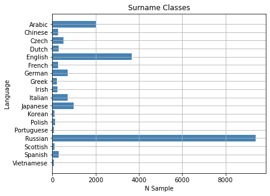

```python
from os import listdir, path

langs, langs_n = [], []
for fn in sorted([_ for _ in listdir(PATH_DATA) if _.endswith('.txt')]):
    langs +=  [path.splitext(path.basename(fn))[0]]

    with open(path.join(PATH_DATA, fn), 'r', encoding="utf8") as fin:
        langs_n += [len(fin.read().splitlines())]

# plot
plt.barh(langs[::-1], langs_n[::-1], color='steelblue')
plt.xlabel('N Sample'); plt.ylabel('Language'); plt.title('Surname Classes')
plt.grid(True)
plt.show()
```

```python
from os import listdir, path

# Letter index 0 is the padding value, i.e. padding to fill up the vector to SEQ_SIZE, necessary for batched
# Note that eventually we will use torch Tensor to represent these fixed length sequences
LetterVocabulary, LetterVocabularyIndex, Index2Voc, Sequences = {' ':0}, 1, {0:' '}, {}
for fn in sorted([_ for _ in listdir(PATH_DATA) if _.endswith('.txt')]):
    lang, seqs = path.splitext(path.basename(fn))[0], []

    if lang not in LANGS:  # test case
        continue

    with open(path.join(PATH_DATA, fn), 'r', encoding="utf8") as fin:
        for row in fin.read().splitlines():
            seq = np.zeros(SEQ_SIZE, dtype=np.int32)
            for i_, letter in enumerate(row.lower()):  # Convert the surname to lower case
#            for i_, letter in enumerate(row):
                if i_ < SEQ_SIZE:
                    if letter not in LetterVocabulary:
                        LetterVocabulary[letter] = LetterVocabularyIndex
                        Index2Voc[LetterVocabularyIndex] = letter
                        LetterVocabularyIndex += 1
                    seq[i_] = LetterVocabulary[letter]
            seqs += [seq]
    Sequences[lang] = seqs

# Sanity check
def print_names(_lang, _k):
    print(''.join([Index2Voc[c] for c in Sequences[_lang][_k]]), Sequences[_lang][_k]) if _lang in LANGS else None

# Some examples
print_names('English', 35)
print_names('Vietnamese', 3)
print_names('Irish', 3)
print_names('Arabic', 1923)
print_names('Czech', 160)
print_names('Chinese', 233)
print_names('German', 1)
print_names('Korean', 69)
print_names('Portuguese', 4)
print_names('Russian', 1678)
```

```
ainley               [ 8 14  7 16 11  6  0  0  0  0  0  0  0  0  0  0  0  0  0  0]
pham                 [25  2  8 15  0  0  0  0  0  0  0  0  0  0  0  0  0  0  0  0]
aodha                [ 8  3 10  2  8  0  0  0  0  0  0  0  0  0  0  0  0  0  0  0]
maalouf              [15  8  8 16  3  4 17  0  0  0  0  0  0  0  0  0  0  0  0  0]
jarzembowski         [21  8  5 13 11 15 18  3 20  9  1 14  0  0  0  0  0  0  0  0]
lu:                  [16  4 27  0  0  0  0  0  0  0  0  0  0  0  0  0  0  0  0  0]
abel                 [ 8 18 11 16  0  0  0  0  0  0  0  0  0  0  0  0  0  0  0  0]
si                   [ 9 14  0  0  0  0  0  0  0  0  0  0  0  0  0  0  0  0  0  0]
araújo               [ 8  5  8 39 21  3  0  0  0  0  0  0  0  0  0  0  0  0  0  0]
bekovich-cherkassky  [18 11  1  3 28 14 22  2 24 22  2 11  5  1  8  9  9  1  6  0]
```

```python
# Sanity
N = sum([len(Sequences[_]) for _ in Sequences])

T = Sequences[LANGS[0]][0].shape[0]

C = len(np.unique(Sequences.keys())[0])

print(N, T, C)
```

```
20074 20 18
```

```python
import itertools

# Pool all sequences and all languages
Seqs = [Sequences[LANGS[_]] for _ in range(C)]
Seqs = list(itertools.chain(*Seqs))

# Number of features is the number of unique characters
M = np.max(Seqs)  # Max sequence length
print(f'M= {M}')
```

```
M= 57
```

```python
# Apriori class balance, i.e. inverse probability of the class
nk = np.array([len(Sequences[LANGS[_]]) for _ in range(C)], dtype=np.float32)
nk = (N/nk)
nk = nk/nk.sum()

# Class weights, inverse apriori probability
WEIGHTS = torch.tensor(nk, dtype=torch.float32)

print(WEIGHTS)
```

```
tensor([0.0032, 0.0059, 0.0439, 0.0227, 0.0396, 0.0425, 0.0163, 0.0580, 0.0507,
        0.0166, 0.0119, 0.1252, 0.0847, 0.1591, 0.0013, 0.1177, 0.0395, 0.1613])
```

```python
# Ground truth
y = [[_]*len(Sequences[LANGS[_]]) for _ in range(C)]
y = np.array(list(itertools.chain(*y)))
```

Data preprocessing is completed.

### Regular Classifiers

Create the data point by the union of one-hot encoded characters, without any temporal knowledge. This will be equivalent bag-of-characters for every name/sequence (i.e. character-vector).

Note that the uppercase letter as the first letter in the surname would help the regular classifiers as they could mark the start of the sequence. In order to keep low bias and demonstrate how RNNs help, all letters are converted to lower case. So that a regular classifier cannot distinguish between first letter 'a' and other 'a's. But an RNN can distinguish as it is learning the order/sequence of the letters.

```python
# One-hot encode every position of the sequence
X = np.empty((N,M))
n = 0
for lang in Sequences.keys():
    for seq in Sequences[lang]:
        sxx = np.zeros((M,), dtype=np.float32)
        for i_ in range(SEQ_SIZE):  # for the duration of the signal
            if seq[i_] > 0:
                sxx[seq[i_]-1] = 1
        X[n] = sxx
        n += 1
```

```python
# sanity - name Khoury - bag of characters
print([Index2Voc[_+1] for _ in range(M) if X[0,_] == 1])

# sanity - name Maalouf - bag of characters, lost second 'a'
print([Index2Voc[_+1] for _ in range(M) if X[5,_] == 1])

# sanity - name Ang - bag of characters
print([Index2Voc[_+1] for _ in range(M) if X[2000,_] == 1])
```

```
['k', 'h', 'o', 'u', 'r', 'y']
['o', 'u', 'a', 'm', 'l', 'f']
['n', 'a', 'g']
```

```python
%%time

# Borrowed from previous lectures
from sklearn.model_selection import StratifiedKFold
from sklearn.preprocessing import StandardScaler
from sklearn.metrics import accuracy_score
from sklearn.naive_bayes import GaussianNB
from sklearn.ensemble import RandomForestClassifier
from sklearn.svm import SVC

def kfold_eval_docs(_clf, _X, _y):
    # Need indexable data structure
    acc = []
    kf = StratifiedKFold(n_splits=10, shuffle=False, random_state=None)
    for train_index, test_index in kf.split(_X, _y):
        _clf.fit(_X[train_index], _y[train_index])
        y_pred = _clf.predict(_X[test_index])
        acc += [accuracy_score(_y[test_index], y_pred)]
    return np.array(acc)

nb = GaussianNB()
acc = kfold_eval_docs(nb, X, y)
print(f'Naive Bayes CV accuracy= {np.mean(acc):.3f} {chr(177)}{np.std(acc):.3f}')

rf = RandomForestClassifier(n_jobs=4, n_estimators=300, max_depth=10, random_state=None, class_weight='balanced')
acc = kfold_eval_docs(rf, X, y)
print(f'Random Forest CV accuracy= {np.mean(acc):.3f} {chr(177)}{np.std(acc):.3f}')

svm = SVC(kernel='rbf', gamma='scale', class_weight='balanced')
acc = kfold_eval_docs(svm, StandardScaler().fit_transform(X), y)
print(f'Support Vector Machine CV accuracy= {np.mean(acc):.3f} {chr(177)}{np.std(acc):.3f}')
```

```
Naive Bayes CV accuracy= 0.060 ±0.036
Random Forest CV accuracy= 0.462 ±0.039
Support Vector Machine CV accuracy= 0.418 ±0.040
CPU times: total: 4min 7s
Wall time: 3min 54s
```

### Elman RNN Classifier

Create the one hot encoded character sequence as a signal for every surname. Make the list of tuples of `(sxx, y)` in order to help to shuffle the training data which can be very important to have unbiased fast RNN training.

- Use `batch_first=True` to mark the first dimension as the batch dimension of the Tensor. RNN will use the Tensor data structure dimensions $\text{batch}\times \text{sequence} \times \text{features}$ or `B x T x M`
- Use `'relu'` as the activation function on Elman RNN
- Use `dropout` of 0.2 when 2 or more hidden layers are provided

As can be seen below, RNN learns the sequences successfully and its performance is comparable to SVM when the first letter is capitalized (left as an Exercise). Below SVM performance is achieved when the surnames are all lower case and this is a more difficult problem (Why?).

**Note** that the Elman RNN performance below heavily depends on the number of epochs and the batch size.

```python
# One-hot encode every position of the sequence
# List of sequence, language tuples for easy shuffling
def get_Xy():
    Xy = []
    for lang in Sequences.keys():
        for seq in Sequences[lang]:
            T = SEQ_SIZE  # necessary for batched
            sxx = np.zeros((T, M))
            for i in range(T):  # for the duration of the signal
                if seq[i] > 0:
                    sxx[i, seq[i]-1] = 1
            Xy += [(torch.tensor(sxx, dtype=torch.float32),
                    torch.tensor([LANGS_CAT[lang]], dtype=torch.int64))]
    return Xy

# Helper functions
def get_X(_Xy):
    return [_[0] for _ in _Xy]

def get_y(_Xy):
    return [int(_[1].data[0]) for _ in _Xy]

# Sanity
Xy = get_Xy()
print(len(Xy))

# printing the confusion matrix below
def get_cm(_y, _p):
    from sklearn.metrics import confusion_matrix
    import pandas as pd

    cm = confusion_matrix(_y, _p, labels=list(range(len(LANGS))))
    display(pd.DataFrame(cm, index=[_[:5] for _ in LANGS], columns=[_[:5] for _ in LANGS]))
```

```
20074
```

```python
# sanity - each surname
print(f'T rows (length of seq), M columns (# of characters, vocabulary) - {Xy[0][0].shape}')

def check_rev(_xy):
    name = ''
    for _ in range(SEQ_SIZE):
        if len(_xy[_].nonzero()) != 0:  # not the append part
            name += Index2Voc[_xy[_].nonzero().numpy()[0][0]+1]
    return name

# sanity
print(check_rev(Xy[0][0]))  # first surname in arabic list
print(check_rev(Xy[1][0]))  # second surname in arabic list
print(check_rev(Xy[2000][0]))  # first surname in chinese list
```

```
T rows (length of seq), M columns (# of characters, vocabulary) - torch.Size([20, 57])
khoury
nahas
ang
```

```python
class My_RNN(nn.Module):

    def __init__(self, n_hidden, n_hid_layers=1, epochs=10, eta=0.0005, batch_size=100, weight=None, info=True):
        """ A PyTorch neural network model based on RNN cell, batched """
        super(My_RNN, self).__init__()

        self.n_hidden= n_hidden  # hidden layer size
        self.n_hid_layers= n_hid_layers  # number of hidden layers
        self.epochs= epochs  # number of learning iterations
        self.eta= eta  # learning rate
        self.B= batch_size  # size of training batch - 1 would not work
        self.info= info  # debug info

        self.rnn, self.outlayer = None, None

        self.softmax = nn.LogSoftmax(dim=1)
        # loss function, since the last layer is nn.LogSoftmax
        self.criterion = nn.NLLLoss(weight=weight)

    def forward(self, _X, _h0):
        output, hn = self.rnn(_X, _h0)
        output = self.outlayer(output[:, -1, :])  # output is batched
        output = self.softmax(output)
        return output, hn

    def init_cell(self, _M):  # Create variations of our RNN by overriding init_cell
        dropout = 0.2 if self.n_hid_layers > 1 else 0
        return nn.RNN(_M, self.n_hidden, self.n_hid_layers,
                      nonlinearity='relu',
                      bias=False, batch_first=True, dropout=dropout)

    def init_hidden(self, _B):  # batch_first = True
        return torch.zeros(self.n_hid_layers, _B, self.n_hidden).to(Gpu)  # Extra dimension - batch

    def fit(self, _Xy):
        from random import shuffle
        import sys
        import torch.optim as optim

        M= _Xy[0][0].shape[1]  # number of features, based on batch input
        C= np.unique([int(_[1].data[0]) for _ in _Xy]).shape[0]  # number of class labels

        self.rnn = self.init_cell(M).to(Gpu)
        self.outlayer = nn.Linear(self.n_hidden, C).to(Gpu)

        self.optimizer = optim.Adam(self.parameters(), lr=self.eta)

        for e in range(self.epochs):
            # Shuffle the input to randomly interleave classes, note that they are tuples, i.e. (x, y)
            shuffle(_Xy)

            N = len(_Xy)
            L, totloss = 0, 0

            while L < N-self.B:
                sxx = torch.stack([_[0] for _ in _Xy[L:L+self.B]]).to(Gpu)  # get the X
                y = torch.tensor([_[1] for _ in _Xy[L:L+self.B]], dtype=torch.int64).to(Gpu)  # get the y
                output, loss = self.train_signal(sxx, y, self.B)

                totloss += loss
                L += self.B

                if self.info:
                    sys.stderr.write(f"\r{e+1:03d}/{self.epochs:4d} | Loss: {loss:6.2f} | "
                                     f"Avg loss: {totloss/(e+1):6.2f} | {y.data.tolist()[0]}")
                    sys.stderr.flush()

    def train_signal(self, _sxx, _y, _B):
        h0 = self.init_hidden(_B)
        self.optimizer.zero_grad()

        output, hn = self.forward(_sxx, h0)

        loss = self.criterion(output, _y)
        loss.backward()
        self.optimizer.step()
        return output, loss.item()

    def predict(self, _sxx):  # Tensor dimensions: B x T x M
        _sxx = torch.stack(_sxx)
        with torch.no_grad():
            h0 = self.init_hidden(_sxx.shape[0])  # reset the hidden layer
            output, hn = self.forward(_sxx.to(Gpu), h0)

        p_values, indices = output.max(dim=1)
        return indices.to('cpu')


# Info about the RNN
print(My_RNN(10, n_hid_layers=1, eta=0.001))
```

```
My_RNN(
  (softmax): LogSoftmax(dim=1)
  (criterion): NLLLoss()
)
```

```python
%%time

Xy = get_Xy()

Acc = []
for _ in range(1):  # Statistical variation

    rnn = My_RNN(128, n_hid_layers=2, epochs=1000, eta=0.005, batch_size=2000, weight=WEIGHTS, info=True).to(Gpu)
    rnn.fit(Xy)

    y_pred = rnn.predict(get_X(Xy))
    Acc += [np.sum(np.array(y_pred) == np.array(get_y(Xy)))/len(y_pred)]

print(f'RNN reclassification Acc= {np.mean(Acc):.2f} {chr(177)}{np.std(Acc):.3f}')
```

```
1000/1000 | Loss:   0.89 | Avg loss:   0.01 | 64
```

```
RNN reclassification Acc= 0.66 ±0.000
CPU times: total: 14min 28s
Wall time: 1min 50s
```

```python
get_cm(get_y(Xy), y_pred)
```

|  | Engli | Arabi | Chine | Czech | Dutch | Frenc | Germa | Greek | Irish | Itali | Japan | Korea | Polis | Portu | Russi | Scott | Spani | Vietn |
| --- | --- | --- | --- | --- | --- | --- | --- | --- | --- | --- | --- | --- | --- | --- | --- | --- | --- | --- |
| Engli | 1121 | 53 | 32 | 288 | 105 | 216 | 904 | 37 | 217 | 124 | 26 | 37 | 28 | 35 | 80 | 243 | 105 | 17 |
| Arabi | 0 | 1681 | 0 | 28 | 3 | 0 | 34 | 0 | 0 | 0 | 176 | 24 | 0 | 52 | 0 | 0 | 2 | 0 |
| Chine | 3 | 0 | 206 | 3 | 0 | 0 | 6 | 0 | 0 | 0 | 0 | 33 | 0 | 0 | 0 | 5 | 0 | 12 |
| Czech | 17 | 2 | 0 | 273 | 5 | 5 | 82 | 0 | 1 | 12 | 13 | 1 | 64 | 1 | 8 | 2 | 33 | 0 |
| Dutch | 1 | 6 | 3 | 6 | 225 | 4 | 48 | 0 | 0 | 1 | 0 | 1 | 1 | 0 | 0 | 0 | 1 | 0 |
| Frenc | 33 | 0 | 2 | 6 | 1 | 177 | 34 | 4 | 1 | 8 | 0 | 0 | 2 | 1 | 4 | 0 | 4 | 0 |
| Germa | 69 | 6 | 1 | 51 | 52 | 23 | 484 | 3 | 4 | 6 | 0 | 5 | 1 | 1 | 2 | 6 | 10 | 0 |
| Greek | 0 | 1 | 0 | 1 | 0 | 0 | 0 | 184 | 0 | 13 | 2 | 0 | 0 | 1 | 0 | 0 | 1 | 0 |
| Irish | 31 | 1 | 0 | 0 | 0 | 2 | 4 | 0 | 181 | 0 | 0 | 0 | 0 | 1 | 1 | 11 | 0 | 0 |
| Itali | 5 | 2 | 0 | 10 | 0 | 5 | 6 | 22 | 0 | 545 | 19 | 0 | 2 | 15 | 0 | 0 | 78 | 0 |
| Japan | 0 | 5 | 2 | 10 | 0 | 0 | 3 | 1 | 0 | 16 | 903 | 6 | 26 | 5 | 0 | 0 | 14 | 0 |
| Korea | 0 | 1 | 5 | 3 | 1 | 0 | 1 | 0 | 0 | 0 | 0 | 79 | 0 | 0 | 0 | 0 | 0 | 4 |
| Polis | 1 | 0 | 0 | 1 | 0 | 1 | 4 | 0 | 0 | 0 | 0 | 0 | 129 | 0 | 0 | 0 | 3 | 0 |
| Portu | 0 | 0 | 0 | 1 | 0 | 0 | 1 | 0 | 0 | 1 | 2 | 0 | 0 | 45 | 0 | 0 | 24 | 0 |
| Russi | 237 | 41 | 18 | 976 | 43 | 79 | 394 | 118 | 20 | 190 | 187 | 44 | 159 | 18 | 6691 | 17 | 170 | 6 |
| Scott | 17 | 1 | 2 | 2 | 0 | 0 | 0 | 0 | 3 | 0 | 0 | 0 | 0 | 1 | 0 | 74 | 0 | 0 |
| Spani | 2 | 0 | 0 | 6 | 0 | 4 | 10 | 2 | 0 | 39 | 3 | 0 | 3 | 25 | 0 | 0 | 204 | 0 |
| Vietn | 1 | 0 | 0 | 0 | 0 | 0 | 0 | 0 | 0 | 0 | 0 | 4 | 0 | 0 | 0 | 0 | 0 | 68 |

```python
%%time

Xy = get_Xy()

cm_y, cm_p = [], []

Acc = []
kf = StratifiedKFold(n_splits=10)
for tr_ix, ts_ix in kf.split(np.arange(len(Xy)), get_y(Xy)):
    rnn = My_RNN(128, n_hid_layers=2, epochs=1000, eta=0.005, batch_size=2000, weight=WEIGHTS, info=True).to(Gpu)

    X_tr = [Xy[_] for _ in tr_ix]  # predict uses X and y as a tuple
    X_ts = get_X([Xy[_] for _ in ts_ix])
    y_ts = get_y([Xy[_] for _ in ts_ix])

    rnn.fit(X_tr)
    y_pred = rnn.predict(X_ts)

    Acc += [np.sum(np.array(y_pred) == np.array(y_ts))/len(y_pred)]

    cm_y += y_ts
    cm_p += y_pred.tolist()

print(f'RNN 10-fold CV Acc= {np.mean(Acc):.2f} {chr(177)}{np.std(Acc):.3f}')
```

```
1000/1000 | Loss:   0.46 | Avg loss:   0.00 | 14
```

```
RNN 10-fold CV Acc= 0.59 ±0.043
CPU times: total: 2h 15min 17s
Wall time: 16min 54s
```

```python
get_cm(cm_y, cm_p)
```

|  | Engli | Arabi | Chine | Czech | Dutch | Frenc | Germa | Greek | Irish | Itali | Japan | Korea | Polis | Portu | Russi | Scott | Spani | Vietn |
| --- | --- | --- | --- | --- | --- | --- | --- | --- | --- | --- | --- | --- | --- | --- | --- | --- | --- | --- |
| Engli | 1243 | 67 | 80 | 215 | 182 | 428 | 386 | 28 | 299 | 89 | 43 | 29 | 14 | 22 | 59 | 437 | 31 | 16 |
| Arabi | 3 | 1949 | 4 | 1 | 0 | 10 | 2 | 1 | 3 | 6 | 15 | 2 | 0 | 2 | 0 | 1 | 0 | 1 |
| Chine | 11 | 2 | 138 | 8 | 4 | 5 | 2 | 0 | 9 | 5 | 4 | 39 | 0 | 0 | 0 | 5 | 1 | 35 |
| Czech | 54 | 14 | 8 | 171 | 16 | 18 | 51 | 9 | 24 | 25 | 19 | 3 | 37 | 1 | 33 | 15 | 19 | 2 |
| Dutch | 59 | 9 | 3 | 23 | 68 | 33 | 64 | 1 | 8 | 10 | 2 | 1 | 1 | 0 | 4 | 10 | 0 | 1 |
| Frenc | 56 | 6 | 3 | 19 | 21 | 84 | 28 | 2 | 11 | 13 | 2 | 0 | 5 | 2 | 8 | 14 | 3 | 0 |
| Germa | 125 | 10 | 13 | 81 | 83 | 69 | 248 | 5 | 15 | 15 | 2 | 9 | 11 | 1 | 7 | 20 | 5 | 5 |
| Greek | 12 | 2 | 1 | 3 | 2 | 8 | 4 | 138 | 4 | 11 | 4 | 0 | 1 | 5 | 0 | 0 | 8 | 0 |
| Irish | 58 | 6 | 3 | 11 | 5 | 22 | 8 | 0 | 79 | 7 | 4 | 6 | 0 | 1 | 5 | 13 | 3 | 1 |
| Itali | 20 | 20 | 5 | 20 | 3 | 21 | 3 | 7 | 7 | 414 | 66 | 1 | 3 | 30 | 5 | 11 | 71 | 2 |
| Japan | 17 | 56 | 9 | 39 | 0 | 12 | 9 | 9 | 12 | 158 | 601 | 7 | 5 | 6 | 10 | 10 | 30 | 1 |
| Korea | 8 | 2 | 34 | 1 | 1 | 4 | 2 | 1 | 2 | 1 | 3 | 17 | 1 | 0 | 0 | 1 | 0 | 16 |
| Polis | 7 | 1 | 1 | 47 | 2 | 8 | 7 | 0 | 2 | 3 | 3 | 0 | 48 | 0 | 9 | 1 | 0 | 0 |
| Portu | 3 | 2 | 0 | 1 | 0 | 8 | 2 | 4 | 0 | 16 | 6 | 0 | 1 | 15 | 0 | 2 | 14 | 0 |
| Russi | 420 | 94 | 64 | 778 | 81 | 156 | 322 | 55 | 197 | 228 | 165 | 25 | 87 | 21 | 6569 | 81 | 54 | 11 |
| Scott | 40 | 2 | 4 | 9 | 0 | 7 | 8 | 1 | 7 | 2 | 1 | 0 | 0 | 1 | 0 | 17 | 1 | 0 |
| Spani | 16 | 12 | 1 | 15 | 8 | 18 | 10 | 15 | 4 | 65 | 23 | 0 | 6 | 21 | 2 | 5 | 76 | 1 |
| Vietn | 4 | 2 | 35 | 0 | 1 | 2 | 1 | 1 | 0 | 0 | 1 | 13 | 0 | 0 | 0 | 3 | 0 | 10 |

### LSTM Classifier

Use the `My_RNN` class and modify hidden layer generation and creation of the RNN layer via overriding `init_hidden` and `init_cell` methods.

Internally, LSTM last layer has default $\tanh$ activation function. It uses two hidden buffers, one for hidden state and one for cell state, and these are passed as a tuple in `init_hidden`.

As can be seen below LSTM classifier is performing superbly among all the classifiers tried in this notebook.

```python
class My_LSTM(My_RNN):

    def __init__(self, n_hidden, n_hid_layers=1, epochs=10, eta=0.0005, batch_size=100, weight=None, info=True):
        """ A PyTorch neural network model based on LSTM RNN cell, batched """
        super(My_LSTM, self).__init__(n_hidden, n_hid_layers=n_hid_layers,
                                      epochs=epochs, eta=eta, batch_size=batch_size, weight=weight, info=info)

    def init_hidden(self, _B):  # batch_first = True
        return (torch.zeros(self.n_hid_layers, _B, self.n_hidden).to(Gpu),
                torch.zeros(self.n_hid_layers, _B, self.n_hidden).to(Gpu))

    def init_cell(self, _M):  # override
        dropout = 0.2 if self.n_hid_layers > 1 else 0
        return nn.LSTM(_M, self.n_hidden, self.n_hid_layers,
                       #nonlinearity='relu',
                       bias=False, batch_first=True, dropout=dropout)

# Info about the RNN
print(My_LSTM(10, n_hid_layers=1, eta=0.001))
```

```
My_LSTM(
  (softmax): LogSoftmax(dim=1)
  (criterion): NLLLoss()
)
```

```python
%%time

Xy = get_Xy()

Acc = []
for _ in range(1):  # Statistical variation

    rnn = My_LSTM(128, n_hid_layers=1, epochs=1000, eta=0.005, batch_size=2000, weight=WEIGHTS, info=True).to(Gpu)
    rnn.fit(Xy)

    y_pred = rnn.predict(get_X(Xy))
    Acc += [np.sum(np.array(y_pred) == np.array(get_y(Xy)))/len(y_pred)]

print(f'RNN reclassification Acc= {np.mean(Acc):.2f} {chr(177)}{np.std(Acc):.3f}')
```

```
1000/1000 | Loss:   0.13 | Avg loss:   0.00 | 64
```

```
RNN reclassification Acc= 0.97 ±0.000
CPU times: total: 14min 34s
Wall time: 1min 49s
```

```python
get_cm(get_y(Xy), y_pred)
```

|  | Engli | Arabi | Chine | Czech | Dutch | Frenc | Germa | Greek | Irish | Itali | Japan | Korea | Polis | Portu | Russi | Scott | Spani | Vietn |
| --- | --- | --- | --- | --- | --- | --- | --- | --- | --- | --- | --- | --- | --- | --- | --- | --- | --- | --- |
| Engli | 3376 | 3 | 8 | 7 | 11 | 42 | 29 | 1 | 55 | 2 | 0 | 6 | 4 | 12 | 2 | 99 | 9 | 2 |
| Arabi | 0 | 2000 | 0 | 0 | 0 | 0 | 0 | 0 | 0 | 0 | 0 | 0 | 0 | 0 | 0 | 0 | 0 | 0 |
| Chine | 0 | 0 | 240 | 0 | 0 | 1 | 0 | 0 | 0 | 0 | 0 | 18 | 0 | 0 | 0 | 1 | 0 | 8 |
| Czech | 0 | 0 | 0 | 505 | 2 | 1 | 2 | 0 | 0 | 0 | 1 | 0 | 5 | 0 | 0 | 3 | 0 | 0 |
| Dutch | 0 | 0 | 2 | 0 | 290 | 2 | 1 | 0 | 1 | 0 | 0 | 0 | 1 | 0 | 0 | 0 | 0 | 0 |
| Frenc | 0 | 0 | 0 | 0 | 2 | 265 | 0 | 0 | 2 | 0 | 0 | 0 | 5 | 0 | 0 | 1 | 2 | 0 |
| Germa | 0 | 1 | 1 | 10 | 24 | 12 | 663 | 0 | 3 | 0 | 0 | 2 | 4 | 0 | 0 | 1 | 2 | 1 |
| Greek | 0 | 0 | 0 | 0 | 0 | 0 | 0 | 203 | 0 | 0 | 0 | 0 | 0 | 0 | 0 | 0 | 0 | 0 |
| Irish | 0 | 0 | 0 | 0 | 0 | 1 | 0 | 0 | 225 | 0 | 0 | 0 | 0 | 0 | 0 | 6 | 0 | 0 |
| Itali | 0 | 0 | 1 | 0 | 2 | 1 | 0 | 0 | 0 | 672 | 0 | 0 | 2 | 9 | 0 | 0 | 22 | 0 |
| Japan | 0 | 1 | 2 | 0 | 0 | 0 | 0 | 0 | 0 | 0 | 985 | 3 | 0 | 0 | 0 | 0 | 0 | 0 |
| Korea | 0 | 0 | 0 | 0 | 0 | 0 | 0 | 0 | 0 | 0 | 0 | 87 | 0 | 0 | 0 | 0 | 0 | 7 |
| Polis | 0 | 0 | 0 | 0 | 0 | 0 | 0 | 0 | 0 | 0 | 0 | 0 | 139 | 0 | 0 | 0 | 0 | 0 |
| Portu | 0 | 0 | 0 | 0 | 0 | 0 | 0 | 0 | 0 | 0 | 0 | 0 | 0 | 74 | 0 | 0 | 0 | 0 |
| Russi | 13 | 0 | 4 | 2 | 0 | 3 | 12 | 0 | 2 | 0 | 1 | 3 | 2 | 0 | 9358 | 4 | 1 | 3 |
| Scott | 0 | 0 | 0 | 0 | 0 | 0 | 0 | 0 | 0 | 0 | 0 | 0 | 0 | 0 | 0 | 100 | 0 | 0 |
| Spani | 0 | 0 | 0 | 0 | 1 | 4 | 0 | 0 | 0 | 1 | 0 | 0 | 1 | 36 | 0 | 0 | 255 | 0 |
| Vietn | 0 | 0 | 0 | 0 | 0 | 0 | 0 | 0 | 0 | 0 | 0 | 0 | 0 | 0 | 0 | 0 | 0 | 73 |

```python
%%time

Xy = get_Xy()

cm_y, cm_p = [], []

Acc = []
kf = StratifiedKFold(n_splits=10)
for tr_ix, ts_ix in kf.split(np.arange(len(Xy)), get_y(Xy)):
    rnn = My_LSTM(128, n_hid_layers=1, epochs=1000, eta=0.005, batch_size=2000, weight=WEIGHTS, info=True).to(Gpu)

    X_tr = [Xy[_] for _ in tr_ix]  # predict uses X and y as a tuple
    X_ts = get_X([Xy[_] for _ in ts_ix])
    y_ts = get_y([Xy[_] for _ in ts_ix])

    rnn.fit(X_tr)
    y_pred = rnn.predict(X_ts)

    Acc += [np.sum(np.array(y_pred) == np.array(y_ts))/len(y_pred)]

    cm_y += y_ts
    cm_p += y_pred.tolist()

print(f'RNN 10-fold CV Acc= {np.mean(Acc):.2f} {chr(177)}{np.std(Acc):.3f}')
```

```
1000/1000 | Loss:   0.15 | Avg loss:   0.00 | 14
```

```
RNN 10-fold CV Acc= 0.69 ±0.030
CPU times: total: 2h 12min 14s
Wall time: 16min 32s
```

```python
get_cm(cm_y, cm_p)
```

|  | Engli | Arabi | Chine | Czech | Dutch | Frenc | Germa | Greek | Irish | Itali | Japan | Korea | Polis | Portu | Russi | Scott | Spani | Vietn |
| --- | --- | --- | --- | --- | --- | --- | --- | --- | --- | --- | --- | --- | --- | --- | --- | --- | --- | --- |
| Engli | 1995 | 54 | 47 | 114 | 99 | 156 | 262 | 21 | 134 | 53 | 36 | 14 | 22 | 10 | 328 | 270 | 39 | 14 |
| Arabi | 0 | 2000 | 0 | 0 | 0 | 0 | 0 | 0 | 0 | 0 | 0 | 0 | 0 | 0 | 0 | 0 | 0 | 0 |
| Chine | 30 | 2 | 132 | 0 | 2 | 2 | 3 | 0 | 1 | 1 | 12 | 36 | 2 | 0 | 12 | 1 | 0 | 32 |
| Czech | 93 | 5 | 3 | 122 | 11 | 3 | 48 | 2 | 2 | 15 | 26 | 3 | 23 | 6 | 140 | 7 | 9 | 1 |
| Dutch | 115 | 0 | 3 | 14 | 47 | 12 | 52 | 1 | 0 | 7 | 2 | 1 | 3 | 0 | 39 | 0 | 1 | 0 |
| Frenc | 106 | 2 | 3 | 5 | 12 | 47 | 26 | 2 | 4 | 16 | 1 | 0 | 4 | 3 | 29 | 4 | 11 | 2 |
| Germa | 173 | 6 | 5 | 48 | 69 | 28 | 214 | 2 | 6 | 6 | 6 | 7 | 10 | 3 | 113 | 18 | 6 | 4 |
| Greek | 20 | 2 | 0 | 2 | 4 | 2 | 0 | 122 | 0 | 7 | 4 | 0 | 2 | 2 | 25 | 1 | 10 | 0 |
| Irish | 103 | 0 | 2 | 1 | 2 | 2 | 7 | 1 | 85 | 2 | 1 | 0 | 0 | 0 | 17 | 4 | 3 | 2 |
| Itali | 44 | 11 | 7 | 19 | 2 | 12 | 3 | 5 | 0 | 363 | 49 | 1 | 5 | 28 | 85 | 0 | 72 | 3 |
| Japan | 20 | 17 | 8 | 18 | 0 | 1 | 1 | 8 | 1 | 41 | 763 | 4 | 5 | 4 | 93 | 0 | 6 | 1 |
| Korea | 11 | 2 | 31 | 1 | 1 | 2 | 4 | 0 | 1 | 0 | 4 | 17 | 0 | 0 | 6 | 0 | 0 | 14 |
| Polis | 10 | 0 | 0 | 26 | 3 | 5 | 6 | 1 | 1 | 1 | 4 | 0 | 48 | 0 | 28 | 1 | 5 | 0 |
| Portu | 14 | 1 | 0 | 3 | 1 | 4 | 0 | 2 | 1 | 15 | 4 | 0 | 0 | 9 | 7 | 0 | 13 | 0 |
| Russi | 504 | 60 | 34 | 297 | 48 | 47 | 200 | 35 | 62 | 102 | 116 | 18 | 62 | 8 | 7750 | 17 | 38 | 10 |
| Scott | 88 | 0 | 2 | 4 | 0 | 1 | 0 | 0 | 3 | 0 | 0 | 0 | 0 | 0 | 1 | 1 | 0 | 0 |
| Spani | 30 | 3 | 3 | 11 | 3 | 11 | 5 | 8 | 1 | 78 | 13 | 2 | 4 | 18 | 37 | 1 | 69 | 1 |
| Vietn | 8 | 1 | 23 | 1 | 2 | 0 | 2 | 0 | 0 | 1 | 1 | 7 | 1 | 0 | 3 | 0 | 0 | 23 |

## References

1. PyTorch GitHub. https://github.com/pytorch. Accessed Oct 2023.
2. Why TensorFlow for Python is dying a slow death. https://thenextweb.com/news/why-tensorflow-for-python-is-dying-a-slow-death. Accessed May 2023.
3. LSTM PtyTorch . https://pytorch.org/docs/stable/generated/torch.nn.LSTM.html. Accessed Oct 2023.

## Exercises

**Exercise 1.** Practice the RNN learning by updating the notebook to speed up the computations. e.g. by scaling down the problem (2 classes?).

**Exercise 2.** Modify the ingest-script to have the first letters as capitalized letters and re-run the regular classifiers.